# Make a choropleth map using the sf approach in R

11/6/2021

### 1. Load and prepare cartographic data

Choropleth maps are maps where some quantity is used to color geographic areas on the map. They are based on polygon layers and cannot be constructed directly from point locations (e.g. specific addresses or latitude/longitude coordinates) or from images (e.g. satellite data). Choropleth maps are often used to map data that vary by country, state, county, or other aggregated unit (e.g. dominant vegetation types in a biome or watershed, demographic variables, or political outcomes).

Usually you start with a dataset that has a variable you want to map, for example, percent of a population in each state under age 30. This would be your “attribute” file. You then need to find a geographic file, often a shapefile, that has the boundaries of your map, e.g., state outlines for the US. The next task is to find the name of the variable in the attribute file and the corresponding name of the variable in the shapefile that is common (or could be common) to both files. Then you need to merge them using that shared variable. Once all that is complete you can begin to start creating the actual map.

Resources for making choropleth maps: https://cengel.github.io/R-spatial/intro.html https://r-spatial.github.io/sf/reference/tidyverse.html https://cfss.uchicago.edu/notes/vector-maps/

```r
require(pacman)  # Gives a confirmation message.
pacman::p_load(pacman, sf, sp, rgdal, raster, rgeos, dplyr, stringr, classInt, RColorBrewer, ggplot2, ggplot2, tidyverse, rgdal, ggthemes) #ggmap, tmap, leaflet,

# DO ONCE for tutorial data only
#download.file("http://bit.ly/R-spatial-data", "R-spatial-data.zip")
#unzip("R-spatial-data.zip", exdir = "data")

# read in geometries
state_sf <- st_read("../gis/cb_2018_us_state_5m/")
str(state_sf)
```

```
## Classes 'sf' and 'data.frame':   56 obs. of  10 variables:
##  $ STATEFP : chr  "31" "53" "35" "46" ...
##  $ STATENS : chr  "01779792" "01779804" "00897535" "01785534" ...
##  $ AFFGEOID: chr  "0400000US31" "0400000US53" "0400000US35" "0400000US46" ...
##  $ GEOID   : chr  "31" "53" "35" "46" ...
##  $ STUSPS  : chr  "NE" "WA" "NM" "SD" ...
##  $ NAME    : chr  "Nebraska" "Washington" "New Mexico" "South Dakota" ...
##  $ LSAD    : chr  "00" "00" "00" "00" ...
##  $ ALAND   : num  1.99e+11 1.72e+11 3.14e+11 1.96e+11 6.77e+11 ...
##  $ AWATER  : num  1.37e+09 1.26e+10 7.29e+08 3.38e+09 1.90e+10 ...
##  $ geometry:sfc_MULTIPOLYGON of length 56; first list element: List of 1
##   ..$ :List of 1
##   .. ..$ : num [1:1516, 1:2] -104 -104 -104 -104 -104 ...
##   ..- attr(*, "class")= chr [1:3] "XY" "MULTIPOLYGON" "sfg"
##  - attr(*, "sf_column")= chr "geometry"
##  - attr(*, "agr")= Factor w/ 3 levels "constant","aggregate",..: NA NA NA NA NA NA NA NA NA
##   ..- attr(*, "names")= chr [1:9] "STATEFP" "STATENS" "AFFGEOID" "GEOID" ...
```

```r
# read "crosswalk" index that connects the attribute file to the geographic boundary file via a shared variable

load("../gis/geoids.Rda")

#geoids <- load("gis/geoids.Rda")
fips <- df.all %>% filter(GeoType == "State")
fips$GeoName <- droplevels(fips$GeoName)
#head(fips)

# insert leading 0s where appropriate
fips$GEOID <- str_pad(fips$GEOID, 2, pad = "0") # uses library(stringr)
#dput(fips$GeoName)
fips$ppstaten <- c("AL", "AK", "AZ", "AR", "CA", "CO", "CT", "DE", "DC",
"FL", "GA", "HI", "ID", "IL", "IN", "IA", "KS", "KY", "LA", "ME", "MD",
"MA", "MI", "MN", "MS", "MO", "MT", "NE", "NV", "NH", "NJ",
"NM", "NY", "NC", "ND", "OH", "OK", "OR", "PA", "RI", "SC",
"SD", "TN", "TX", "UT", "VT", "VA", "WA", "WV", "WI", "WY")

#View(fips)
```

### 2. Merge data attributes that you want to map

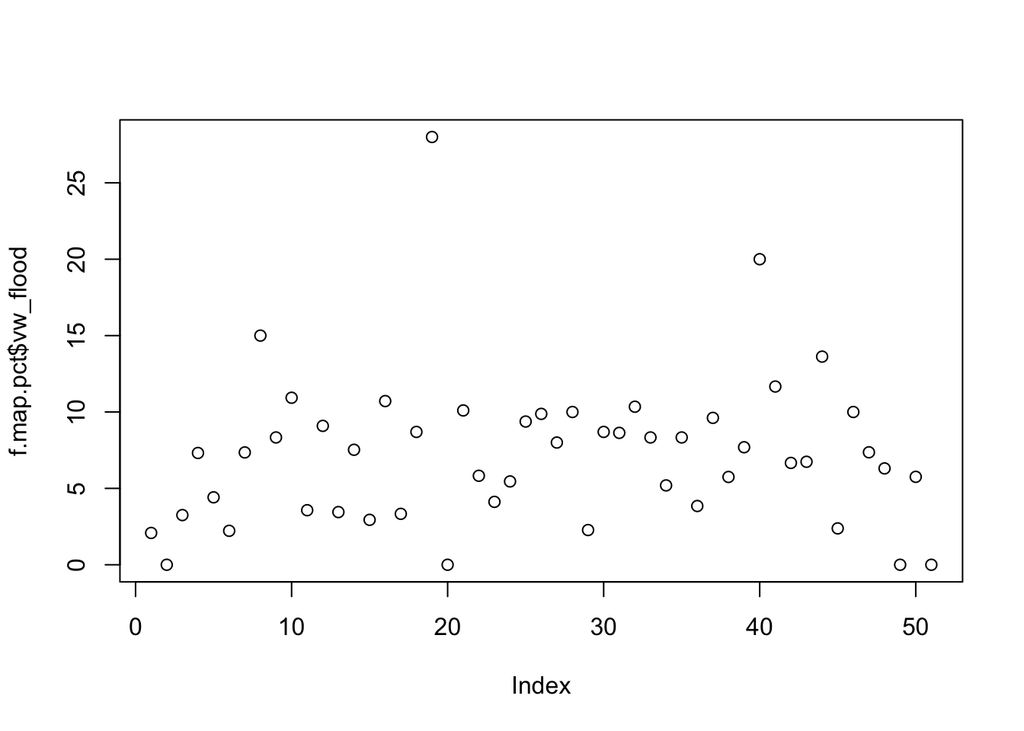

```r
opinions <- read.csv("../surveydata/ccam_flooding.csv")
names(opinions) <- tolower(names(opinions))
flood <- opinions %>% dplyr::select(caseid, wave, ppreg9, ppstaten, x948w)

flood.summary <- flood %>%
  dplyr::group_by(ppstaten,x948w) %>%
  dplyr::summarize(N = n()) %>%
  #dplyr::mutate(freq = N/sum(N), pct = round((freq*100), 2)) %>%
  dplyr::mutate(freq = N/sum(N), pct = (freq*100)) %>%
  dplyr::filter(x948w == "Very worried") %>%
  dplyr::summarize(vw_flood = sum(pct))

f.map.pct <- left_join(fips,flood.summary)
f.map.pct <- f.map.pct %>% replace_na(list(vw_flood = 0))
plot(f.map.pct$vw_flood)
```

### 3. Construct US map

```r
# Merge survey data into the sf object

# Do not do this - it does not produce an 'sf' object:
# state_sf <- left_join(state_sf, f.map.pct, by = c("STUSPS" = "ppstaten"))

# Do this instead:
state_sf_merged <- merge(state_sf, f.map.pct, by.x = "STUSPS", by.y = "ppstaten")


p <- ggplot(state_sf_merged) +
  geom_sf(aes(fill=vw_flood))

# remove AK, HI, PR
state_sf_merged <- state_sf_merged %>% filter(STUSPS!= c("AK", "PR", "HI"),)

# get quantile breaks. # Can add .00001 offset to catch the lowest value
breaks_qt <- classIntervals(c(min(state_sf_merged$vw_flood), state_sf_merged$vw_flood), n = 5, style = "quantile")
breaks_qt
```

```
## style: quantile
##   one of 111,930 possible partitions of this variable into 5 classes
##        [0,3.317073) [3.317073,5.797304) [5.797304,8.133333)       [8.133333,10)
##                  10                  10                  10                   9
##             [10,28]
##                  11
```

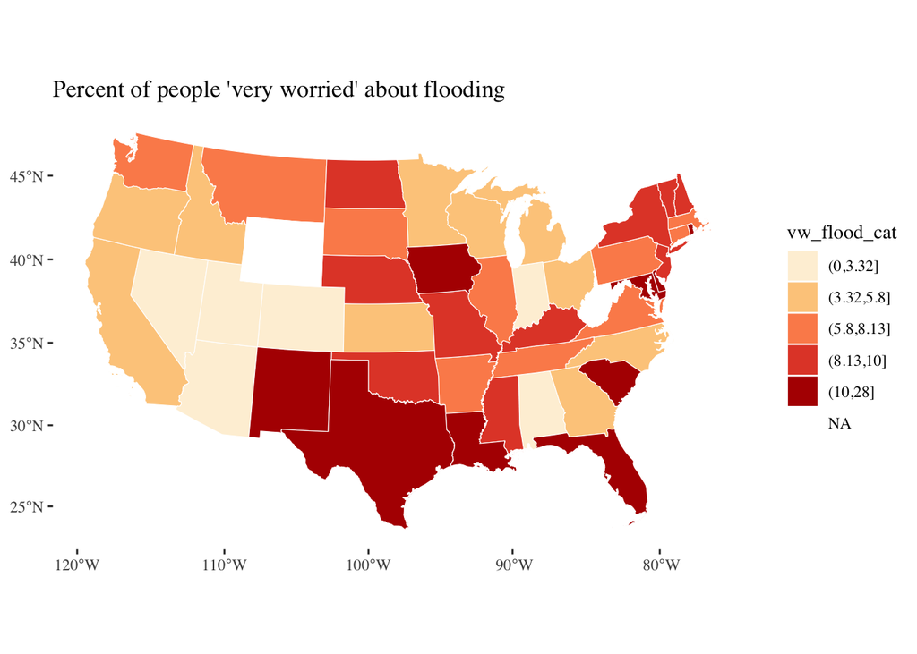

```r
vwf_sf <- mutate(state_sf_merged, vw_flood_cat = cut(vw_flood, breaks_qt$brks))
#View(vwf_sf)
p <- ggplot(vwf_sf) +
  geom_sf(aes(fill=vw_flood_cat), color="white", size = 0.2) +
  scale_fill_brewer(palette = "OrRd") +
  coord_sf(crs = "+proj=aea +lat_1=25 +lat_2=50 +lon_0=-100") +
  ggtitle("Percent of people 'very worried' about flooding") +
  theme_tufte()

p
```

```r
ggsave("../output/veryworried_flooding2.png", width=8.76, height=5.74,  dpi=300)


# CLEAN UP #################################################

# Clear packages
p_unload(dplyr) # Clear specific packages
p_unload(all)  # Easier: clears all add-ons
detach("package:datasets", unload = TRUE)  # For base

# Clear console
cat("\014")  # ctrl+L
```